# Lesson 23: Inference for Bivariate Data

Preparation

- Word Document
- PDF Document

## Solutions

**Please note that the steps show rounded numbers, but that the final answers to the problems are calculated without rounding.**

Problem

Part

Solution

1

-

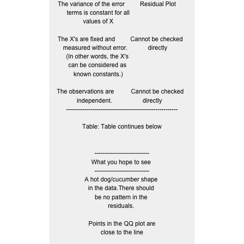

2

-

$\beta_0$ is the parameter y-intercept for the population  
$\beta_1$ is the parameter slope for the population.  
$\epsilon$ is the error term–a normal random variable.

3

A

There is a linear relationship between X and Y. - Yes points on the scatter plot are close together and in a ‘hotdog’ shape.

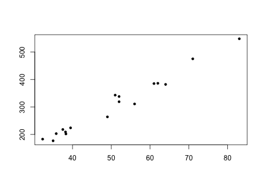

3

B

The error term $\epsilon$ is normally distributed - Yes. Made a QQ plot of the residuals and the points are close to linear.

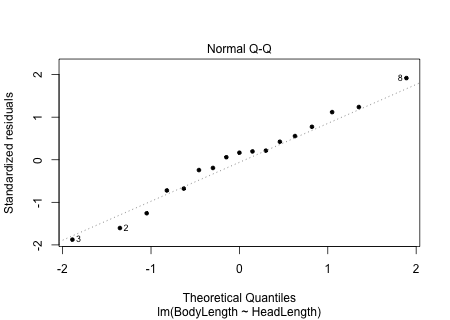

3

C

The variance of the error terms is constant for all values of X - Yes there is no megaphone shape in the residual scatter plot.

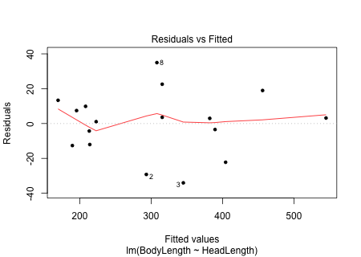

3

D

X’s are fixed and measured without error. (In other words, the X’s can be considered as known constants.) We will assume that X’s have been measured accurately and precisely.

3

E

The observations are independent. - We will assume that the Y’s are independent.

4

A

$H_0: \beta_1 = 0$  
$H_a: \beta_2 \neq 0$

4

B

$\text{Let alpha} = 0.05$

4

C

It is a t-test statistic  
$t = 22.675$

4

D

$\text{P-value} = 0.000000000000508 < 0.05$  
Therefore we reject the null hypothesis.

4

E

We have sufficient evidence to suggest that there is a linear relationship between the head length and the body length of the Gharial crocodiles.

5

-

The 95% confidence interval for the true slope of the regression line is (6.704, 8.096)